# GLM - Pigs

# Background

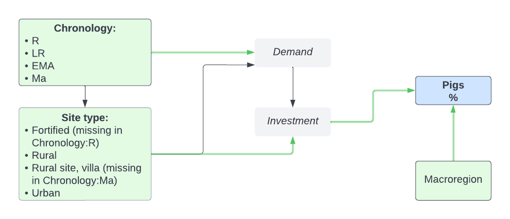

Graphical representation of the model.

Ideas behind the model:

- *Demand* and *Investment* are unknown and cannot be estimated: in a sense, `Pigs` % might help in estimating them.
- `Chronology` influences the *demand* (more or less people, dietary preferences, etc.) and the site `Type` (as some sites do not exist in other chronologies, or settlement patterns change).
- The site `Type` influences the *investment* (low to high) and consequently the pigs husbandry.
- *Investment* is also influenced by *demand* (again, low to high). For instance, sites with high demand are `Fortified` or `Urban` sites. Sites with high investment might be `Villas` in the Late Roman phase.
- The `Macroregion` is an important confounding variable, as it shows diverging trends for `Pigs` %.

# Data processing

```r
####################
## Data pre-processing
####################

library(here)
library(tidyverse)

Animals_Df <- read.csv(here("/Users/robertoragno/Downloads/betabin_test/Zooarch_Condensed_with_altitude.csv"), header=TRUE, sep=";")

Animals_Df$Tot_NISP <- rowSums(Animals_Df[c(16:22)], na.rm = T)

# 1. Subsetting the dataframe
Animals_Df <- Animals_Df[c(1,16,17,18,20,25,4,5,6,7,10)]

# 2. Merge some categories in the 'Type' column
Animals_Df$Type <- str_replace(Animals_Df$Type, "Rural site, mansio", "Rural")
Animals_Df$Type <- str_replace(Animals_Df$Type, "Religious, monastery", "Religious")
Animals_Df$Type <- str_replace(Animals_Df$Type, "Castle", "Fortified")
Animals_Df$Type <- str_replace(Animals_Df$Type, "Castrum", "Fortified")
Animals_Df$Geo <- str_replace(Animals_Df$Geo, "Hilltop", "Hill")

# 3. Remove the categories 'Necropolis' and 'Religious' as they might skew
# the results.
Animals_Df <- filter(Animals_Df, Type!="Necropolis" & Type!="Religious" & Type!="Shipwreck" & Type!="Urban, amphitheater")

# 4. Exclude the castrum of Ostia, very strong outlier and regardless only fortified
# roman site
Animals_Df <- subset(Animals_Df, !(Chronology=="R" & Type=="Fortified"))

# Convert to factors
Animals_Df[,c(7:9,11)] <- lapply(Animals_Df[,c(7:9,11)], factor)

# Specify chronological order
Animals_Df$Chronology <- factor(Animals_Df$Chronology, levels = c("R", "LR", "EMA", "Ma"))

# Convert NAs to 0
Animals_Df[is.na(Animals_Df)]<-0

# Create copies
Animals_Df2 <- Animals_Df
Animals_Df_fort <- Animals_Df
Animals_Df_villas <- Animals_Df

# Convert to proportions just the
Animals_Df[,c(2:5)] <- Animals_Df[,c(2:5)]/Animals_Df$Tot_NISP

# Simplifying: Urban vs Rural
Animals_Df2 <- subset(Animals_Df2, Type=="Rural" | Type=="Urban")
Animals_Df2 <- droplevels(Animals_Df2)

Animals_Df_fort <- subset(Animals_Df_fort, Type=="Fortified")
Animals_Df_fort <- droplevels(Animals_Df_fort)

Animals_Df_villas <- subset(Animals_Df_villas, Type=="Rural site, villa")
Animals_Df_villas <- droplevels(Animals_Df_villas)
```

```
## [1] "Number of samples:"
```

```
##
##   R  LR EMA  Ma
## 169 174 130  60
```

```
## [1] "Chronological means and sd:"
```

```
## # A tibble: 4 × 3
##   Chronology  mean    SD
##   <fct>      <dbl> <dbl>
## 1 R           0.43  0.22
## 2 LR          0.36  0.19
## 3 EMA         0.33  0.16
## 4 Ma          0.37  0.15
```

Plots showing very high variability in each site type:

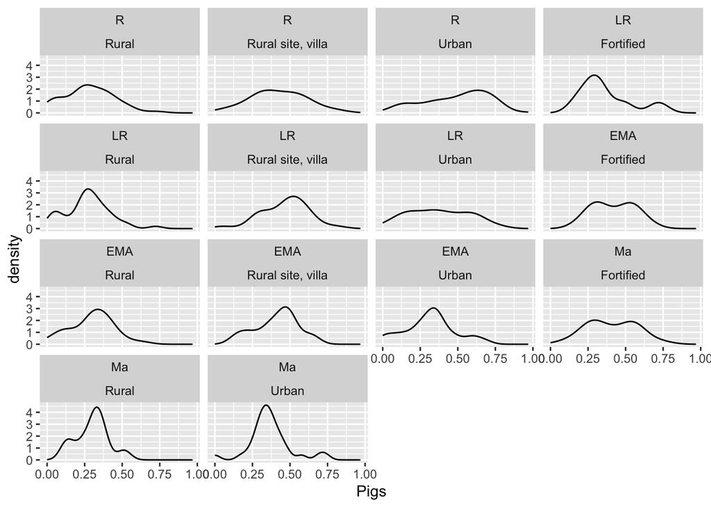

# Test 3: Rethinking

Formula:
$$P_{i} \sim
BetaBinomial(NISP_{i}, \bar{p}_{i} , \Theta )$$

$$logit(\bar{p}_{i}) = \alpha_{[TCid]}$$

$$\alpha_{j} \sim Normal(0,1.5)$$

$$\Theta = \phi + 2$$

$$\phi \sim Exponential(1)$$

```r
library(rethinking)

d <- Animals_Df2
d$TC_id <- as.integer(interaction(d$Type, d$Chronology))
dat <-  list( P=d$Pigs , N=d$Tot_NISP , TC_id=d$TC_id )

# pbar is the mean of the distribution

m12.1 <- ulam(
    alist(
        P ~ dbetabinom( N , pbar , theta ),
        logit(pbar) <- a[TC_id],
        a[TC_id] ~ dnorm( 0 , 1.5 ),
        transpars> theta <<- phi + 2.0,
        phi ~ dexp(1)
    ), data=dat , chains=4
    )
```

[output not shown]

```r
post <- extract.samples( m12.1 )
precis( post , depth=2 )
```

```
##              mean         sd       5.5%       94.5%       histogram
## a[1]  -0.93194983 0.11980171 -1.1230726 -0.73870391       ▁▁▁▅▇▇▂▁▁
## a[2]  -0.07957447 0.08003094 -0.2056535  0.04359014    ▁▁▁▃▇▇▇▃▁▁▁▁
## a[3]  -0.97130372 0.12755291 -1.1773353 -0.76470284       ▁▁▃▇▇▅▂▁▁
## a[4]  -0.58782681 0.08446830 -0.7218520 -0.44925804    ▁▁▁▂▅▇▇▅▂▁▁▁
## a[5]  -0.80200432 0.15340741 -1.0459825 -0.55527318     ▁▁▁▂▅▇▇▅▂▁▁
## a[6]  -0.76392151 0.09907629 -0.9246665 -0.60953444 ▁▁▁▁▁▂▃▇▇▇▅▃▁▁▁
## a[7]  -0.72779273 0.23781237 -1.1103781 -0.35869579       ▁▁▂▇▇▅▂▁▁
## a[8]  -0.45448579 0.14523867 -0.6912774 -0.22812538     ▁▁▁▃▅▇▅▃▁▁▁
## phi    3.79716070 0.40553251  3.1801679  4.45452620 ▁▁▂▃▇▇▇▅▃▂▁▁▁▁▁
## theta  5.79716070 0.40553251  5.1801680  6.45452620 ▁▁▂▃▇▇▇▅▃▂▁▁▁▁▁
```

```r
# postcheck( m12.1 )
```

The variation to the formula that I would like to apply is the following, where the dispersion $\theta$ varies accordingly to the `TC_id` interaction parameter. I am using the same parameter of the $\alpha$ intercept because I want the dispersion for each intercept ( = I want them in the same for cycle).

$$P_{i} \sim BetaBinomial(NISP_{i},
\bar{p}_{i} , \theta )$$

$$logit(\bar{p}_{i}) = \alpha_{[TCid]}$$

$$\alpha_{j} \sim Normal(0,1.5)$$

$$\Theta = \phi_{[TCid]} + 2$$

$$\phi_{j} \sim Exponential(1)$$

Judging from the STAN output of the previous model (`m12.1`), it looks like $\theta$ is already varying according to the index `TC_id` (as it is iteratively multiplied by pbar), although I am not getting what I need: phi[1], phi[2], etc.

[output not shown]

Anyway, if I try to implement the second formula above I get an error:

[output not shown]

```r
m12.2 <- ulam(
    alist(
         P ~ dbetabinom( N , pbar , theta ),
         logit(pbar) <- a[TC_id],
         a[TC_id] ~ dnorm( 0 , 1.5 ),
         theta <- phi[TC_id] + 2.0,
         phi[TC_id] ~ dexp(1)
    ), data=dat, chains=4
     )
```

## Plots

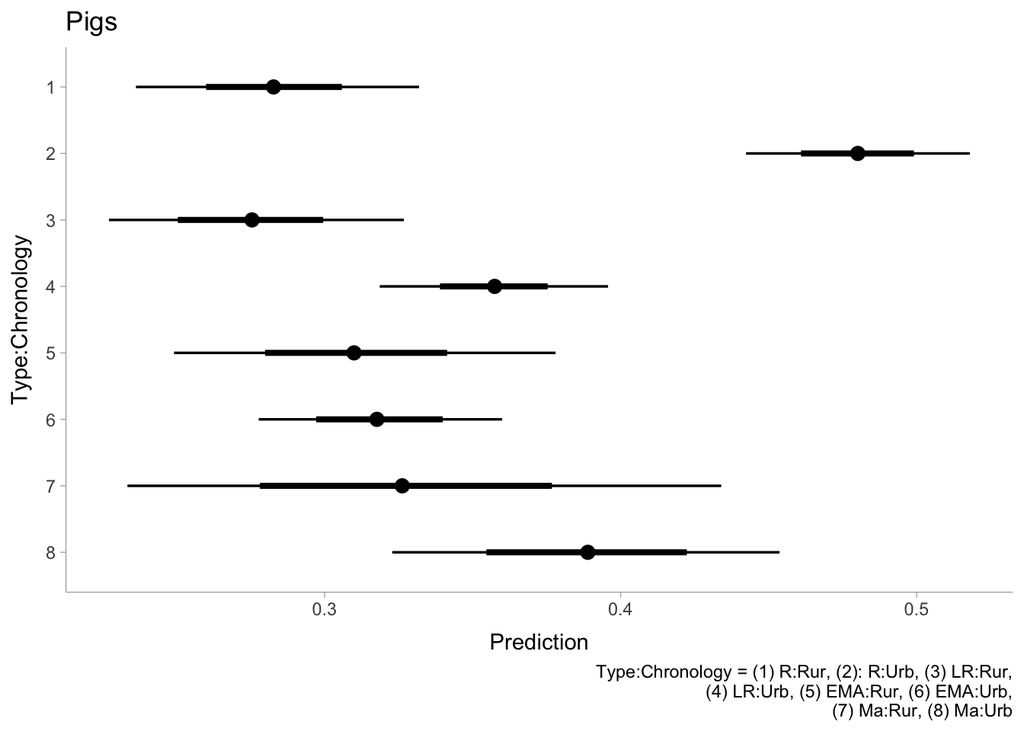